# Seurat Analysis on Dummy Data

Sean Pierre

2022-06-17

## Spatial Transcriptomics Seurat analysis based on: https://satijalab.org/seurat/articles/pbmc3k_tutorial.html

Loading in the data and creating a Seurat Object

```r
dummy.data <- Read10X(data.dir = "~/Desktop/test/week/outs/filtered_feature_bc_matrix")

dummy <- CreateSeuratObject(counts = dummy.data, project = "dummyKid", min.cells = 3, min.features = 200)
dummy
```

```
## An object of class Seurat
## 16842 features across 1597 samples within 1 assay
## Active assay: RNA (16842 features, 0 variable features)
```

In online example, filtering was done on cells with >5% mitochondrial counts, however in test data, Kidneys have been damaged which would lead to increased mitochondrial expression; Different metrics needed?

FeatureScatter can be used to visualize feature-feature relationships, as well as, metadata comparison. This can be useful for data filtering. Filtering cells with over 6000/under 500 features or >50% mitochondrial DNA?

```r
dummy[["percent.mt"]] <- PercentageFeatureSet(dummy, pattern = "^mt-") #Calculates the percentage of couns originating from a set of features

head(dummy@meta.data, 5) #Meta data for first 5 cells
```

```
##                    orig.ident nCount_RNA nFeature_RNA percent.mt
## AAACCGGGTAGGTACC-1   dummyKid      17774         4957   1.851018
## AAACCGTTCGTCCAGG-1   dummyKid      10577         3897  14.191170
## AAACCTCATGAAGTTG-1   dummyKid       9137         3320  10.528620
## AAACGAGACGGTTGAT-1   dummyKid      11866         4121   7.989213
## AAACTGCTGGCTCCAA-1   dummyKid      14251         4588   3.929549
```

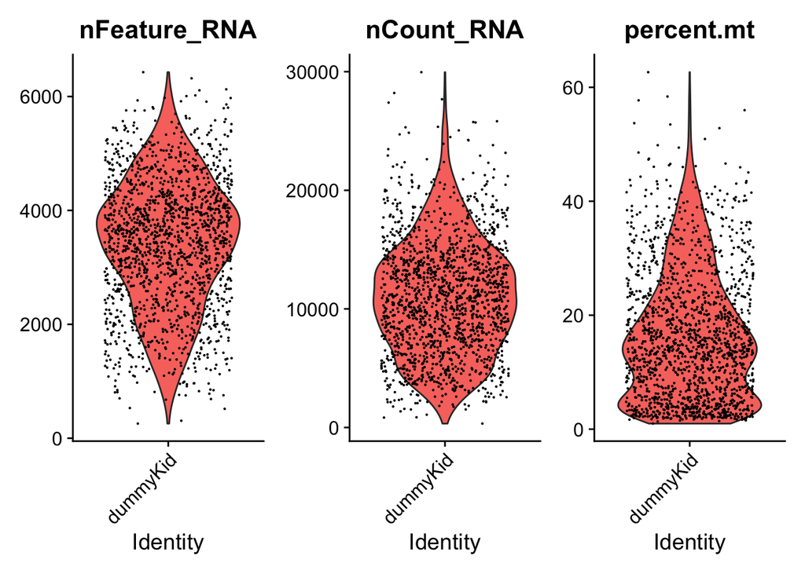

```r
VlnPlot(dummy, features = c("nFeature_RNA", "nCount_RNA", "percent.mt"), ncol = 3)
```

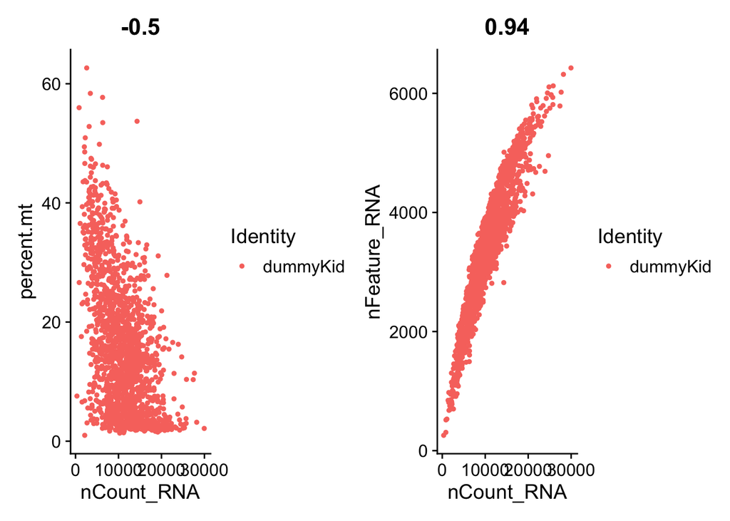

```r
plot1 <- FeatureScatter(dummy, feature1 ="nCount_RNA", feature2 = "percent.mt")
plot2 <- FeatureScatter(dummy, feature1 = "nCount_RNA", feature2 = "nFeature_RNA")
plot1 + plot2
```

```r
dummy <- subset(dummy, subset = nFeature_RNA > 500 & nFeature_RNA < 6000 & percent.mt < 5)
dummy <- NormalizeData(dummy)

dummy <- FindVariableFeatures(dummy, selection.method = "vst", nfeatures = 2000)
top10 <-  head(VariableFeatures(dummy), 10)

plot1 <- VariableFeaturePlot(dummy)
plot2 <- LabelPoints(plot = plot1, points = top10, repel = TRUE)
```

```
## When using repel, set xnudge and ynudge to 0 for optimal results
```

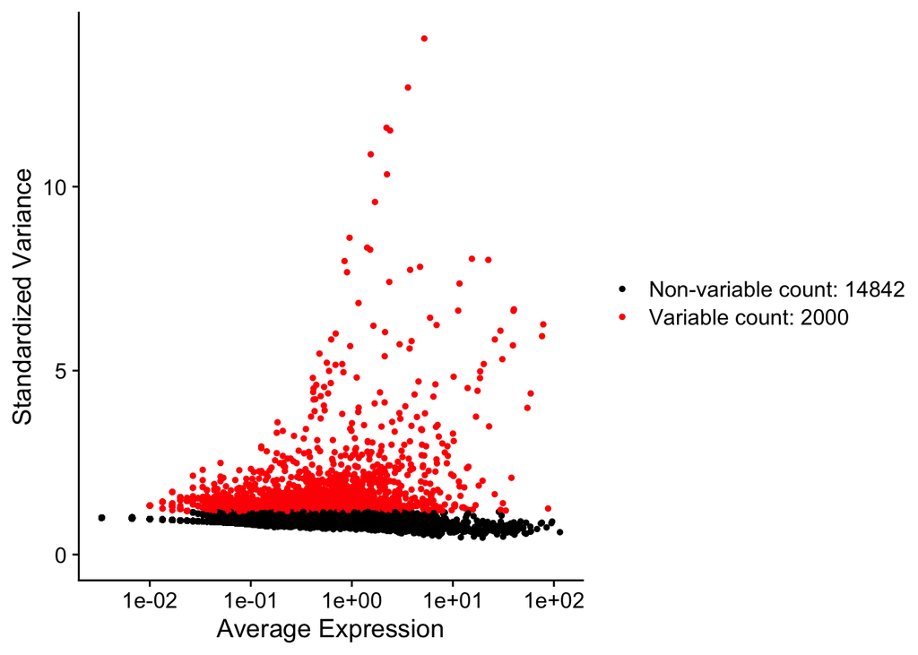

```r
plot1
```

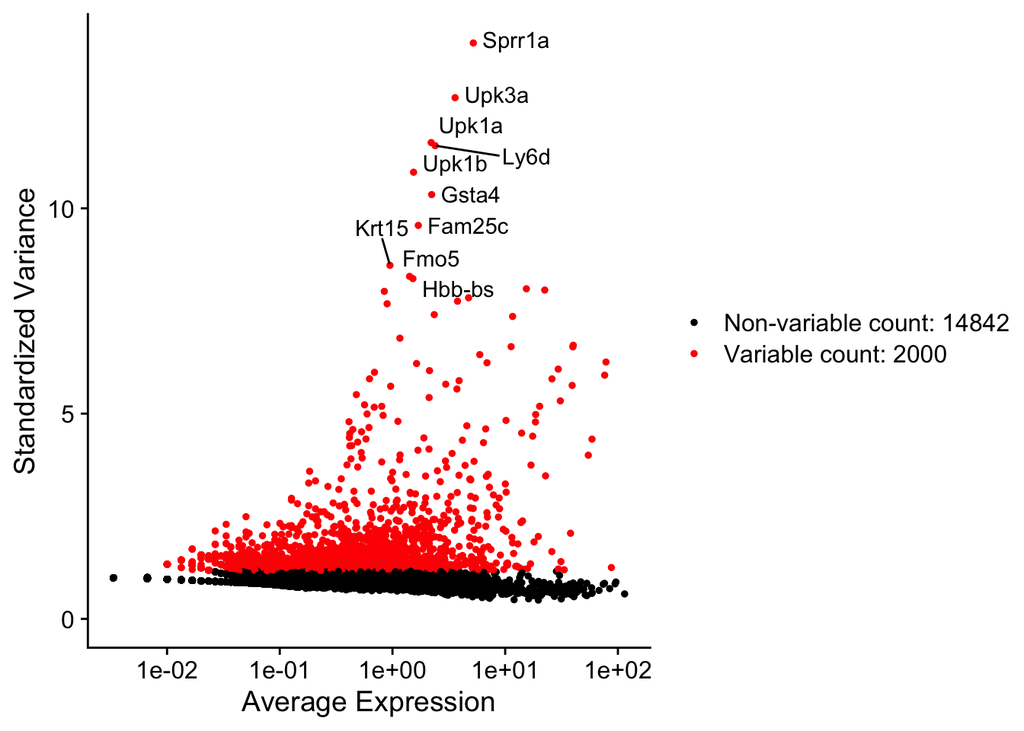

```r
plot2
```

Linear transformation or scaling, standard for dimensionality reduction so that highly expressed genes don’t dominate downstream analysis.

Run PCA on the scaled data based on previously determined variable features. What are the possible variable features?

in DimHeatMap(), cells and features are ordered according to PCA scores.

```r
all.genes <- rownames(dummy)
#length(all.genes)  -- 16842

dummy <- ScaleData(dummy, features = all.genes)
dummy <- RunPCA(dummy, features = VariableFeatures(object = dummy))
```

```
## PC_ 1
## Positive:  Cryab, Aqp2, Akr1b3, Muc20, Gstm2, Fxyd4, Fcgbp, Aqp4, Aldh1a3, Psca
##     Plet1, Tmem45b, Gm43305, Hspa1b, Tmem30b, 1110008P14Rik, Sgk1, AU021092, Mal, Bcam
##     Lypd2, Igfbp5, Avpr2, Krt18, Gstm1, Spink8, Rnf183, Cck, Sbspon, Sptssb
## Negative:  Cd74, H2-Eb1, H2-Aa, H2-Ab1, Mgp, C1qa, Lyz2, Sparc, C1qb, Tyrobp
##     C1qc, Col3a1, Apoe, Cst3, Fn1, Bgn, Cd52, B2m, Col1a1, Psap
##     Ctss, Col1a2, Ifi27l2a, Gpx3, Laptm5, Fcer1g, Ctsb, Igfbp4, Selenop, Serpinh1
## PC_ 2
## Positive:  Cdh16, Cd24a, Cldn10, Tsc22d1, Cldn19, Lcn2, Rab3ip, Defb29, Cd59a, Gal3st1
##     Dcaf11, Clcnka, Apela, Spink8, Bsnd, Cacnb3, Bcl6, Blnk, Pax8, Rapgef3
##     Cd59b, Tmem176b, Psat1, Ly6c1, Hoxb5os, Gmpr, Nudt4, Smagp, Ddr1, Timp3
## Negative:  Upk1a, Ly6d, Upk1b, Upk2, Gsta4, Upk3a, Sprr1a, Fxyd3, Ctse, Fmo5
##     Snx31, Krt5, Sprr2a3, Fam25c, Krt19, Aldh3a1, Trim29, Vsig2, Foxa1, Cnn1
##     Cbr2, Capn13, Aldh3b2, Lmo1, Anxa8, Fer1l4, Depp1, Cyp4f15, Sptlc3, Sfn
## PC_ 3
## Positive:  Cxcl12, Ifitm1, Coch, Cntn1, Heph, Smoc2, Cpxm2, Gsn, Ntrk2, Gas6
##     Mfap5, Dpt, Myl9, Prss23, Col6a4, Mrvi1, Ramp3, Aqp1, Prom1, Cfh
##     Frzb, Umod, Crabp1, Alx1, Tafa5, Aebp1, Crym, Adam12, Ppp1r1a, Nrep
## Negative:  Nphs2, Ltbp2, C3, Nphs1, Tmsb4x, Podxl, Serpine1, Glyat, Alpl, Slc13a1
##     Ear2, Rab3b, Myom2, Clic5, Clic3, H2-DMb2, Slc34a1, Gc, Aldob, Retnla
##     Cpn1, Pdzk1, Nes, Enpep, Spink1, Trib2, Cltrn, Gsta2, Cda, Mucl1
## PC_ 4
## Positive:  Gc, Serpina1b, Slc27a2, Sema3c, Havcr1, Thy1, Ccr2, Tinag, Aoc1, Cyp2j13
##     Keg1, Egfr, Cyp2j11, Slc6a18, Serpina10, Slc17a1, Trac, Cd9, Cyp2j5, Trf
##     Slc3a1, Cgref1, Cd3d, Slc23a1, Paqr5, Tmigd1, Ccl8, Ubd, Aadac, Hao2
## Negative:  Nphs2, Podxl, Nphs1, Myom2, Rab3b, Clic5, Pcsk6, Ptpro, Tm4sf1, Igfbp2
##     Ren1, Sfrp2, Clic3, Fgfbp1, Cldn5, Wt1, Gpihbp1, Cdkn1c, Rhpn1, Ehd3
##     Nes, Ripor1, Sema3e, Tmem54, Ddn, Synpo, Hba-a1, Enpep, Mustn1, Hba-a2
## PC_ 5
## Positive:  Serpina1f, Kap, Slc27a2, Slc5a10, Ppp1r1a, Keg1, Lrp2, Akr1c21, ccdc198, Havcr1
##     Mpv17l, Gcnt1, Fbp1, Napsa, Ttc36, Mep1a, Slc6a18, Hao2, Aadat, Spink1
##     Defb1, Cyp2j5, Slc23a1, Clcnkb, Slc17a3, Fxyd2, Cltrn, Slc12a1, Wfdc15b, Amn
## Negative:  Tmsb4x, Trf, Heg1, Bcl2a1a, Trbc2, Plbd1, Pdia2, Cldn11, Cxcr3, Ptprcap
##     Traf3ip3, Clec4a1, Itgb2, Selplg, Mpeg1, Rac2, Bcl2a1d, Mgl2, Ptprc, Fabp5
##     Ccl17, Ccl22, Laptm5, Lsp1, Cyth4, Serpina3n, Ccl9, Thy1, Lipa, Clec4n
```

```r
print(dummy[["pca"]], dims = 1:5,nfeatures = 5)
```

```
## PC_ 1
## Positive:  Cryab, Aqp2, Akr1b3, Muc20, Gstm2
## Negative:  Cd74, H2-Eb1, H2-Aa, H2-Ab1, Mgp
## PC_ 2
## Positive:  Cdh16, Cd24a, Cldn10, Tsc22d1, Cldn19
## Negative:  Upk1a, Ly6d, Upk1b, Upk2, Gsta4
## PC_ 3
## Positive:  Cxcl12, Ifitm1, Coch, Cntn1, Heph
## Negative:  Nphs2, Ltbp2, C3, Nphs1, Tmsb4x
## PC_ 4
## Positive:  Gc, Serpina1b, Slc27a2, Sema3c, Havcr1
## Negative:  Nphs2, Podxl, Nphs1, Myom2, Rab3b
## PC_ 5
## Positive:  Serpina1f, Kap, Slc27a2, Slc5a10, Ppp1r1a
## Negative:  Tmsb4x, Trf, Heg1, Bcl2a1a, Trbc2
```

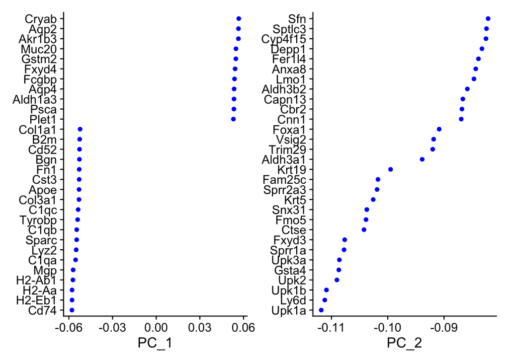

```r
VizDimLoadings(dummy, dims = 1:2, reduction = "pca")
```

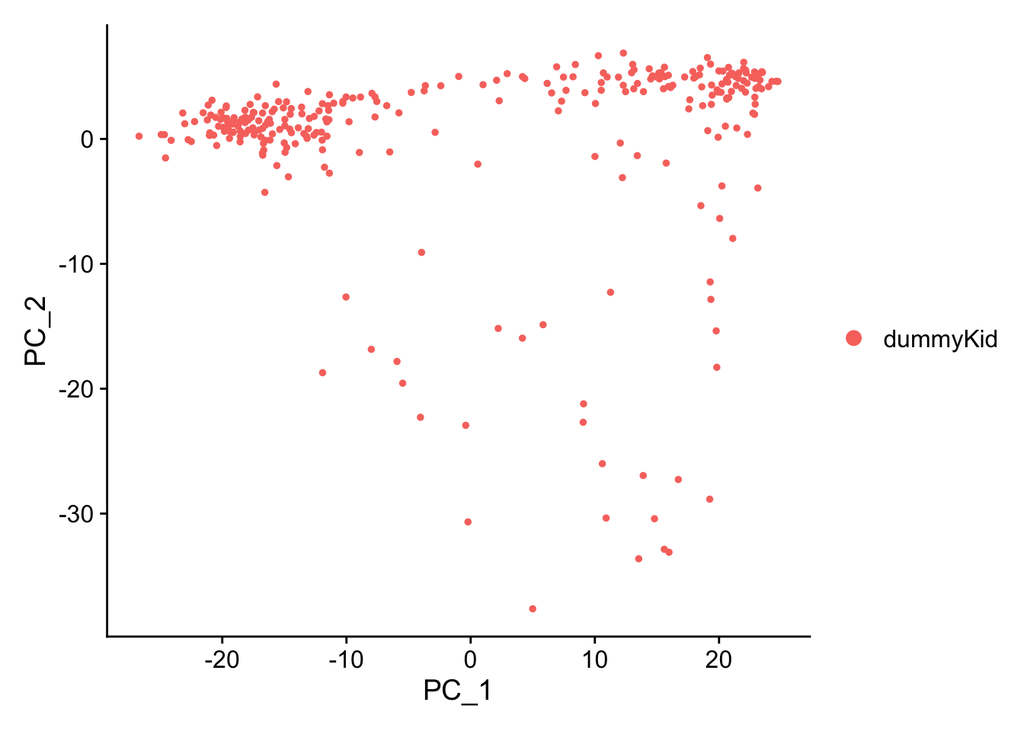

```r
DimPlot(dummy, reduction = "pca")
```

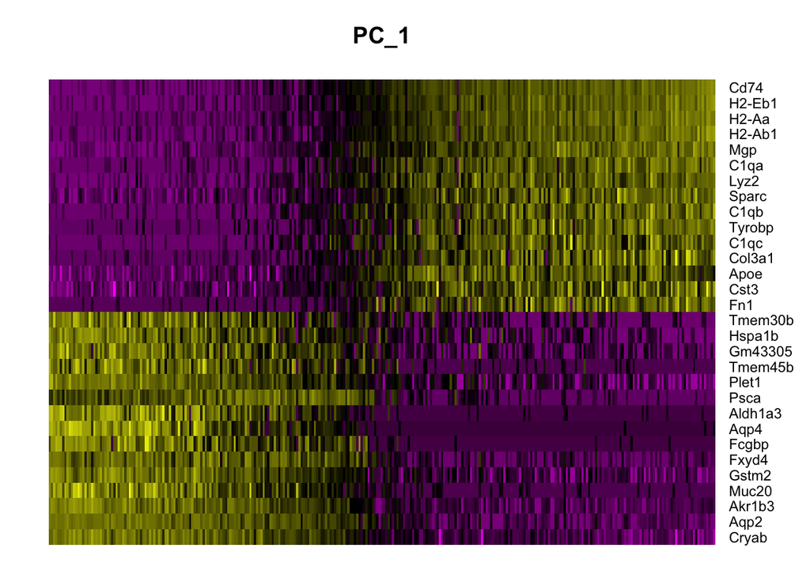

```r
DimHeatmap(dummy, dims = 1, cells = 500, balanced = TRUE)
```

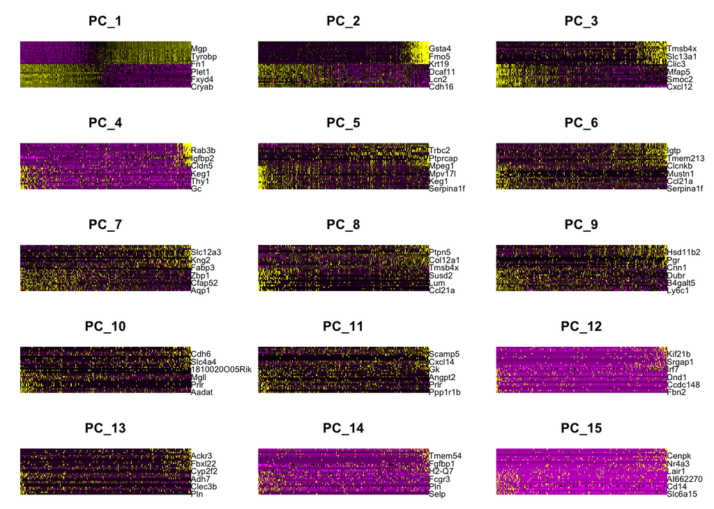

```r
DimHeatmap(dummy, dims = 1:15, cells = 500, balanced = TRUE)
```

To Determine how many PCs to include and which are significant, perform a resampling test (JackStraw Procedure). Process can take a long time, More approximate technique ElbowPlot() used to save time.

Significant PCs are those with low p-value features. Drop off can be seen after PC 8. Elbow in plot ranks where majority of true signal is captured based on location of elbow bend. Recommended to err on the higher side when choosing the parameter. Too little PCs significantly/adveresly alters data.

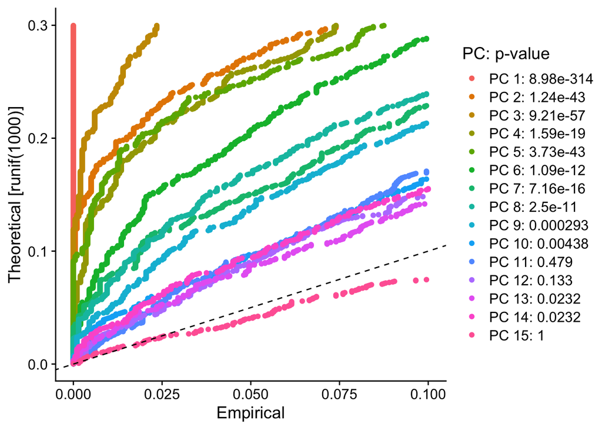

```r
dummy <- JackStraw(dummy, num.replicate = 100)
dummy <-  ScoreJackStraw(dummy, dims = 1:15)

JackStrawPlot(dummy, dims = 1:15)
```

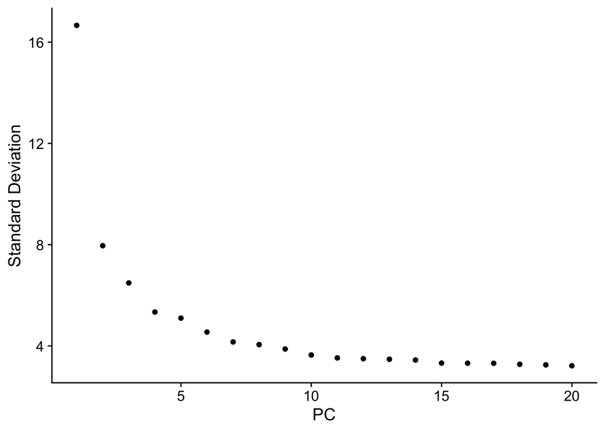

```r
ElbowPlot(dummy)
```

Clustering based on K-nearest neighbor and optimization using Louvain algorithm. Increasing resolution increases the number of clusters, where more are needed with larger datasets.

```r
dummy <- FindNeighbors(dummy, dims = 1:8)
dummy <-  FindClusters(dummy, resolution = 0.5)
```

```
## Modularity Optimizer version 1.3.0 by Ludo Waltman and Nees Jan van Eck
##
## Number of nodes: 299
## Number of edges: 8092
##
## Running Louvain algorithm...
## Maximum modularity in 10 random starts: 0.7845
## Number of communities: 4
## Elapsed time: 0 seconds
```

```r
# Look at cluster IDs of the first 5 cells
head(Idents(dummy), 5)
```

```
## AAACCGGGTAGGTACC-1 AAACTGCTGGCTCCAA-1 AAAGGGCAGCTTGAAT-1 AAATTTGCGGGTGTGG-1
##                  1                  0                  0                  1
## AACAACTGGTAGTTGC-1
##                  0
## Levels: 0 1 2 3
```

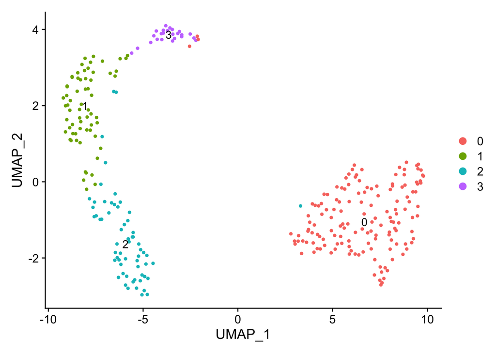

```r
dummy <- RunUMAP(dummy, dims = 1:8)

DimPlot(dummy, reduction = "umap", label = TRUE)
```

```r
# find all markers of cluster 2
cluster2.markers <- FindMarkers(dummy, ident.1 = 2, min.pct = 0.25)
head(cluster2.markers, n = 5)
```

```
##                p_val avg_log2FC pct.1 pct.2    p_val_adj
## Lypd2   3.218057e-25  1.7723162 1.000 0.525 5.419852e-21
## Igfbp7  2.497654e-24  0.8005141 1.000 1.000 4.206549e-20
## Clcnka  9.577928e-21  1.3081373 0.967 0.563 1.613115e-16
## S100a11 1.456138e-20  0.8436540 1.000 0.992 2.452427e-16
## Apela   1.929865e-20  1.4203595 0.967 0.580 3.250278e-16
```

```r
#For cluster 0
cluster0.markers <- FindMarkers(dummy, ident.1 = 0, logfc.threshold = 0.25, test.use = "roc", only.pos = TRUE)

# find all markers distinguishing cluster 3 from clusters 0 and 2
cluster3.markers <- FindMarkers(dummy, ident.1 = 3, ident.2 = c(0, 2), min.pct = 0.25)
head(cluster3.markers, n = 5)
```

```
##                p_val avg_log2FC pct.1 pct.2    p_val_adj
## Sprr2a3 1.455486e-33   1.795940 0.833 0.029 2.451329e-29
## Snx31   3.119362e-33   1.825693 0.917 0.052 5.253629e-29
## Ctse    4.922776e-32   1.570197 0.875 0.048 8.290939e-28
## Upk2    1.536531e-31   2.382349 0.917 0.062 2.587825e-27
## Krt5    1.422281e-29   2.124759 0.958 0.086 2.395405e-25
```

```r
# find markers for every cluster compared to all remaining cells, report only the positive
# ones
dummy.markers <- FindAllMarkers(dummy, only.pos = TRUE, min.pct = 0.25, logfc.threshold = 0.25)
dummy.markers %>%
    group_by(cluster) %>%
    slice_max(n = 2, order_by = avg_log2FC)
```

```
## # A tibble: 8 × 7
## # Groups:   cluster [4]
##      p_val avg_log2FC pct.1 pct.2 p_val_adj cluster gene
##      <dbl>      <dbl> <dbl> <dbl>     <dbl> <fct>   <chr>
## 1 3.37e-49       3.74 1     0.64   5.67e-45 0       Cd74
## 2 6.16e-49       3.53 0.993 0.56   1.04e-44 0       H2-Aa
## 3 1.69e-30       2.45 1     0.897  2.84e-26 1       Akr1b3
## 4 2.90e-31       2.33 1     0.987  4.89e-27 1       Cryab
## 5 3.22e-25       1.77 1     0.525  5.42e-21 2       Lypd2
## 6 6.48e-20       1.62 1     0.697  1.09e-15 2       Igfbp2
## 7 5.26e-21       3.88 1     0.287  8.86e-17 3       Sprr1a
## 8 3.32e-22       3.56 1     0.265  5.60e-18 3       Upk3a
```

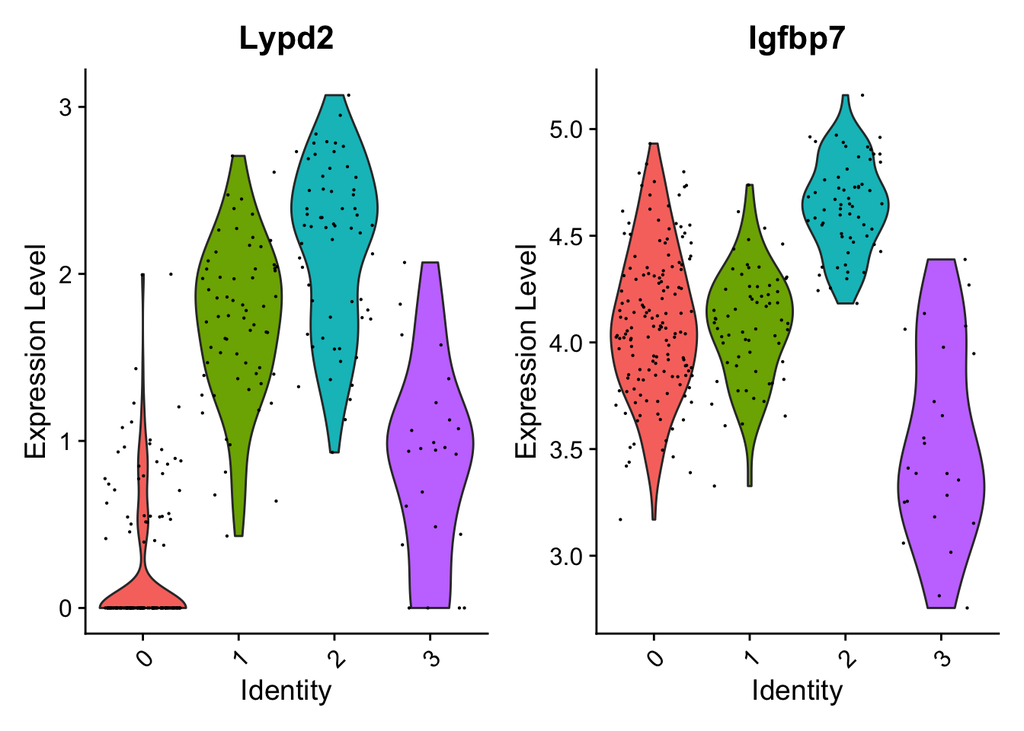

```r
VlnPlot(dummy, features = c(row.names(cluster2.markers)[1], row.names(cluster2.markers)[2]))
```

```r
# # you can plot raw counts as well
# VlnPlot(dummy, features = c("NKG7", "PF4"), slot = "counts", log = TRUE)
#
# FeaturePlot(dummy, features = c("MS4A1", "GNLY", "CD3E", "CD14", "FCER1A", "FCGR3A", "LYZ", "PPBP",
#     "CD8A"))
```